# Data exploration and visualisation

Bernard Silenou and Henrik Schanze

2023-12-02

- After imparting and cleaning your data, the next aim before modelling is to understand your data.
- Essential tools to attain this aim are *summary statistics* and *plots*.

## Goals

- Be able to calculate a range of summary statistics on numeric data
- Be able to draw plots and export out of R

# Summary statistics

- Summary statistics are used to summarize a data in order to communicate the largest amount of information as simply as possible.
- Measures often used are arithmetic mean, variance or standard deviation, and correlation coefficient.
- The *obama_vs_mccain* dataset contains the fractions of people voting for Obama and McCain in the 2008 US presidential elections.
- We load this data from the R package *learningr* and use it in subsequent examples:

```r
data(obama_vs_mccain, package = "learningr")
votesObama <- obama_vs_mccain$Obama
```

Let {x} be the votes for Obama.

### Measure of location:

`mean(x)`: sum of x divided by the length

```r
mean(votesObama)
```

```
## [1] 51.28941
```

`median(x)`: 50% of x is above and 50% is below

```r
median(votesObama)
```

```
## [1] 51.38
```

### Measure of rank:

`min(x)`: minimum value of x

```r
min(votesObama)
```

```
## [1] 32.54
```

`max(x)`: maximum value of x

```r
max(votesObama)
```

```
## [1] 92.46
```

`quantile(x, 0.25)`: 25% of x is below this value; `quantile(x, 0.50)`== median(x)

```r
quantile(votesObama, 0.50)
```

```
##   50%
## 51.38
```

```r
median(votesObama)
```

```
## [1] 51.38
```

```r
quantile(votesObama)
```

```
##     0%    25%    50%    75%   100%
## 32.540 42.755 51.380 57.335 92.460
```

### Measure of variation:

`sd(x)`: standard deviation, square sd to get variance or use `var(x)`

```r
sd(votesObama)
```

```
## [1] 11.0938
```

```r
var(votesObama)
```

```
## [1] 123.0723
```

```r
sd(votesObama)**2
```

```
## [1] 123.0723
```

`range(x)`: gives min and max values

```r
range(votesObama)
```

```
## [1] 32.54 92.46
```

`IQR(x)`: interquartile range == 75th percentile minus 25th percentile

```r
IQR(votesObama)
```

```
## [1] 14.58
```

### Measure of position or count:

`x[1]`: first element in x

```r
votesObama[1]
```

```
## [1] 38.74
```

`x[length(x)]`: last element in x

```r
votesObama[length(votesObama)]
```

```
## [1] 32.54
```

**Quick exercise**: what is the last last but one element in `votsObama`?

### Other summary statistics functions:

`summary(x)`: generic function to compute multiple statistics at once

```r
summary(votesObama)
```

```
##    Min. 1st Qu.  Median    Mean 3rd Qu.    Max.
##   32.54   42.76   51.38   51.29   57.34   92.46
```

```r
summary(obama_vs_mccain)
```

```
##         State        Region       Obama           McCain         Turnout
##  Alabama   : 1   IV     : 8   Min.   :32.54   Min.   : 6.53   Min.   :50.80
##  Alaska    : 1   I      : 6   1st Qu.:42.76   1st Qu.:40.39   1st Qu.:61.05
##  Arizona   : 1   III    : 6   Median :51.38   Median :46.80   Median :64.90
##  Arkansas  : 1   V      : 6   Mean   :51.29   Mean   :47.00   Mean   :64.09
##  California: 1   VIII   : 6   3rd Qu.:57.34   3rd Qu.:55.88   3rd Qu.:67.95
##  Colorado  : 1   VI     : 5   Max.   :92.46   Max.   :65.65   Max.   :78.00
##  (Other)   :45   (Other):14                                   NA's   :4
##   Unemployment      Income        Population          Catholic
##  Min.   :3.40   Min.   :19534   Min.   :  563626   Min.   : 6.00
##  1st Qu.:5.05   1st Qu.:23501   1st Qu.: 1702662   1st Qu.:12.00
##  Median :5.90   Median :25203   Median : 4350606   Median :21.00
##  Mean   :6.01   Mean   :26580   Mean   : 6074128   Mean   :21.67
##  3rd Qu.:7.25   3rd Qu.:28978   3rd Qu.: 6656506   3rd Qu.:29.00
##  Max.   :9.40   Max.   :40846   Max.   :37341989   Max.   :46.00
##                                                    NA's   :2
##    Protestant        Other       Non.religious       Black          Latino
##  Min.   :26.00   Min.   :0.000   Min.   : 5.00   Min.   : 0.4   Min.   : 1.20
##  1st Qu.:46.00   1st Qu.:2.000   1st Qu.:12.00   1st Qu.: 3.1   1st Qu.: 4.30
##  Median :54.00   Median :3.000   Median :15.00   Median : 7.4   Median : 8.20
##  Mean   :53.84   Mean   :3.286   Mean   :16.04   Mean   :11.1   Mean   :10.32
##  3rd Qu.:62.00   3rd Qu.:4.000   3rd Qu.:19.00   3rd Qu.:15.2   3rd Qu.:12.05
##  Max.   :80.00   Max.   :8.000   Max.   :34.00   Max.   :50.7   Max.   :46.30
##  NA's   :2       NA's   :2       NA's   :2
##   Urbanization
##  Min.   :   1.2
##  1st Qu.:  45.8
##  Median : 101.2
##  Mean   : 385.6
##  3rd Qu.: 221.4
##  Max.   :9856.5
##
```

`length(x)`: the number of element in x

```r
length(votesObama)
```

```
## [1] 51
```

```r
dim(obama_vs_mccain)
```

```
## [1] 51 15
```

```r
dim(obama_vs_mccain)[1] # the same as nrow(obama_vs_mccain)
```

```
## [1] 51
```

```r
dim(obama_vs_mccain)[2] # the same as ncol(obama_vs_mccain)
```

```
## [1] 15
```

`table(is.na(x))`: count the number of missing and non missing values

```r
table(is.na(votesObama))
```

```
##
## FALSE
##    51
```

`length(unique(x))`: count the number of unique value

```r
length(unique(obama_vs_mccain$Region))
```

```
## [1] 10
```

`cor(x)`: calculates correlations between numeric vectors, “pearson” (default)

```r
cor(obama_vs_mccain$Obama, obama_vs_mccain$McCain)
```

```
## [1] -0.9981189
```

`cov(x)`: calculates covariance between numeric vectors, “pearson” (default)

```r
with(obama_vs_mccain, cov(Obama, McCain)) # the same as cov(obama_vs_mccain$Obama, obama_vs_mccain$McCain)
```

```
## [1] -121.6998
```

# Plots

## Systems of plots

R has three systems of graphics: *base*, *grid*, and *lattice*.

**Base graphics** is easy to get started with but hard to extend to new graph types. It will be used for a greater part of this section.

**Grid graphics** provides greater flexibility but require writing much lines of code. Example is package ggplot2–most modern and widely used.

**Lattice graphics** is built on top of the grid system, providing high-level functions for all the common plot types. Plot output can be saved as objects, edited and later plotted.

The three systems are, sadly, mostly incompatible, thus recommended to choose one system for a project. ggplot2 is a good choice.

## Scatter plot

It is used to explore the relationship between two continuous variables

### Using base R

Example: Does voters *Income* affect *Turnout* at the polls?

`plot(x)` to plot scatter plot. NA are omitted by default.

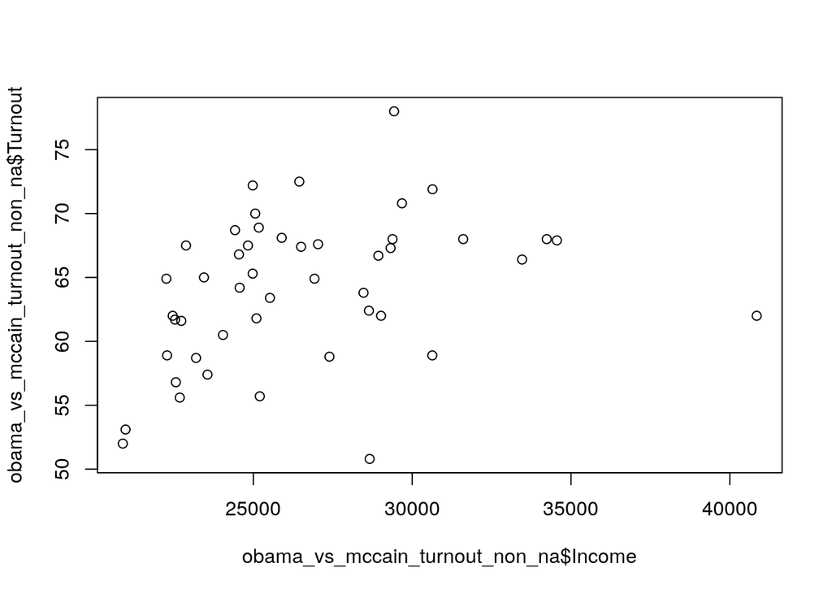

```r
# Deleting NA
obama_vs_mccain_turnout_non_na = obama_vs_mccain[!is.na(obama_vs_mccain$Turnout), ]
# plotting scatter plot
plot(obama_vs_mccain_turnout_non_na$Income, obama_vs_mccain_turnout_non_na$Turnout)
```

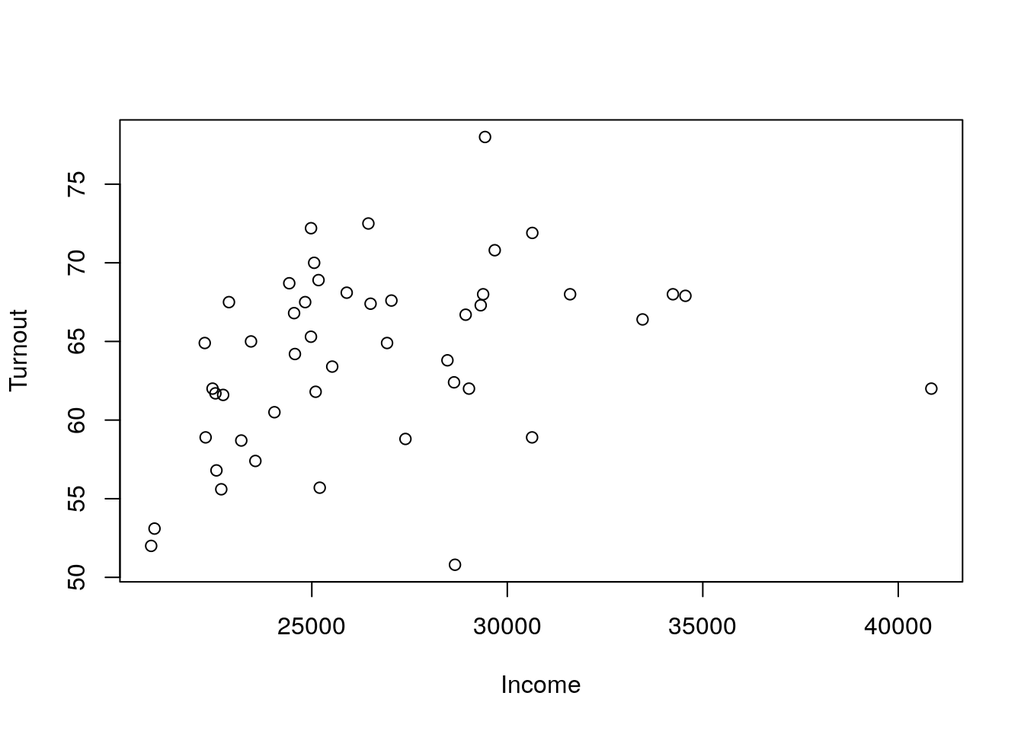

```r
# or using with command
with(obama_vs_mccain_turnout_non_na, plot(Income, Turnout))
```

We can edit the plot by using various parameters as described in the help document `? plot` or `?? plot`

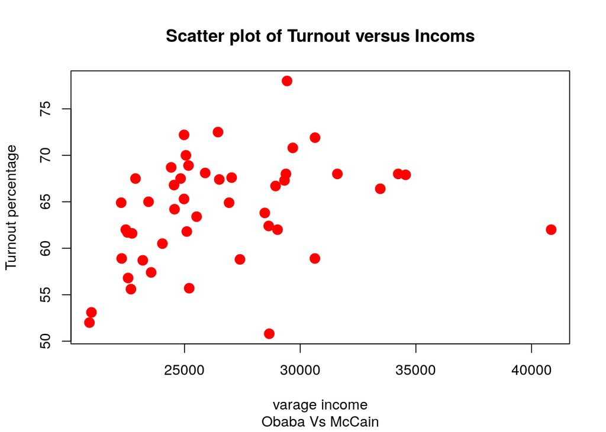

```r
with(obama_vs_mccain_turnout_non_na, plot(Income, Turnout, type = "p", main = "Scatter plot of Turnout versus Incoms",
                                          sub= "Obaba Vs McCain", xlab = "varage income", ylab = "Turnout percentage",
                                          col = "red", pch = 19, cex = 1.5 ))
```

Positive correlation between income and turnout

### Using ggplot2 package

Example: Does voters *Income* affect *Turnout* at the polls?

`ggplot()` to construct a plot. It takes a *dataframe* as its first argument and an *aesthetic* as its second.

`geom_...()` to add e.g. points/line on the plot

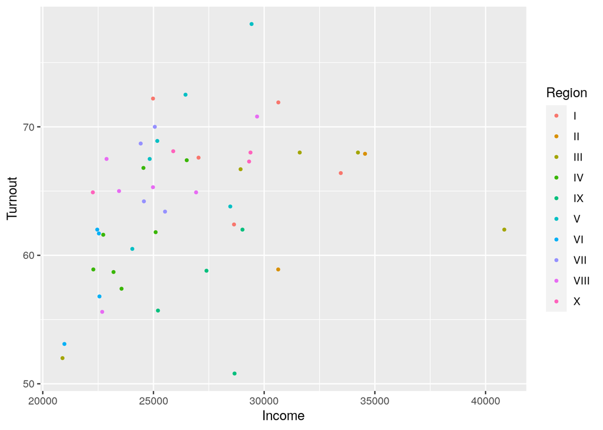

```r
library(ggplot2)
gg1 = ggplot(obama_vs_mccain_turnout_non_na, aes(Income, Turnout, colour = Region)) + # colour points by region
geom_point(shape = 20)
print(gg1)
```

To draw individual plots for each region, we add a *facet* using the function `facet_wrap`.

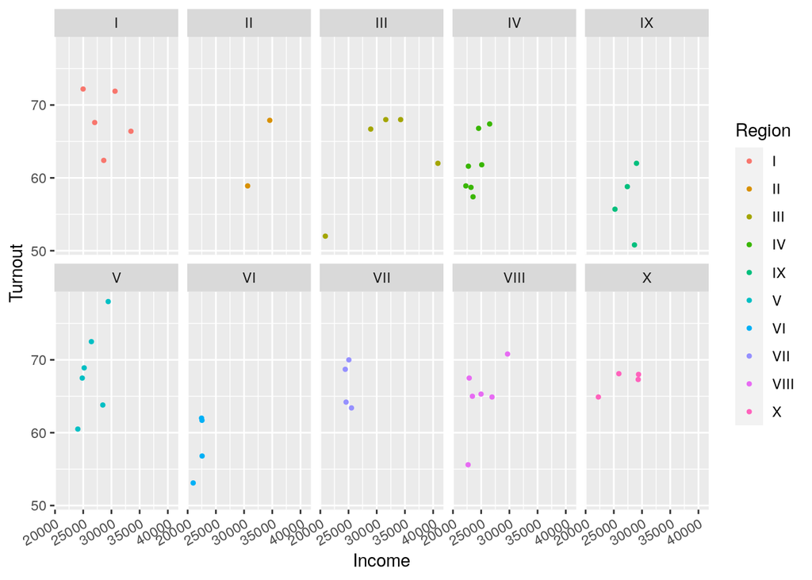

```r
gg2 = gg1 +
  facet_wrap(~ Region, ncol = 5) +
  theme(axis.text.x = element_text(angle = 30, hjust = 1))   # to rotate x axis
plot(gg2)
```

## Getting help

- [Posit Community, formally known as RStudio community](https://community.rstudio.com/)
- [Stack Overflow link for ggplot](https://stackoverflow.com/questions/tagged/ggplot2?sort=frequent&pageSize=50)
- [ggplot2 GitHub](https://github.com/tidyverse/ggplot2)
- [ggplot2 references for further reading](https://r4ds.hadley.nz/data-visualize)